# Progress Memo 1

Final Project  
Data Science 2 with R (STAT 301-2)

Author

Chelsea Angwenyi

Published

March 12, 2024

**Github Repo Link**

[my github repo url](https://github.com/stat301-2-2024-winter/final-project-2-chelsea-a)

## Data source

My data came from the UC Irvine Machine Learning Repository and is called [Predict Students’ Dropout and Academic Success](https://archive.ics.uci.edu/dataset/697/predict+students+dropout+and+academic+success). This data is from one higher education institution (acquired from several disjoint databases) related to students enrolled in different undergraduate degrees, such as agronomy, design, education, nursing, journalism, management, social service, and technologies. The dataset includes information known at the time of student enrollment (academic path, demographics, and socioeconomic factors) and the student’s academic performance at the end of the first and second semesters.

The dataset was created in a project that aims to contribute to the reduction of academic dropout and failure in higher education, by using machine learning techniques to identify students at risk at an early stage of their academic path, so that strategies to support them can be put into place.

The dataset includes information known at the time of student enrollment – academic path, demographics, and social-economic factors.

The problem is formulated as a three category classification task (dropout, enrolled, and graduate) at the end of the normal duration of the course and there is a strong imbalance towards one of the classes. I will be using the data to build classification models to predict students’ dropout and academic success. Where the higher education institution is located and the kinds of the institution are not disclosed.

This dataset is relatively small with 4,424 observations. This dataset has 37 variables 36 of which are predictor variables. There are different types of predictors — multiple numerical and categorical predictor variables. There is a mix of categorical and numeric variables with 10-factor variables.

## Why this data

I chose this data because I am a social policy major and am interested in education policy. I thought that this prediction dataset would be ideal for me because I have previously done a project on education outcomes as well.

## Data quality & complexity check

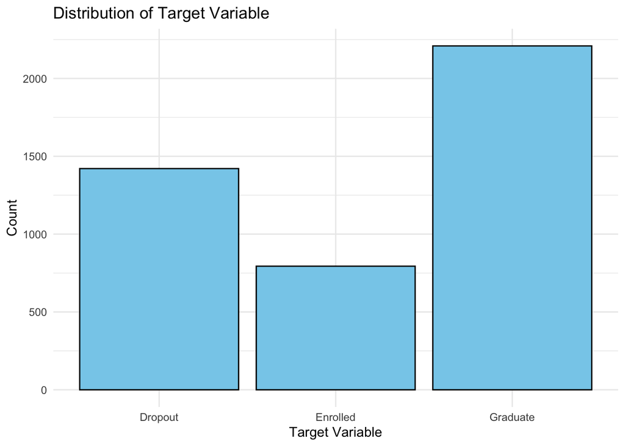

| target | n |
| --- | --- |
| Dropout | 1421 |
| Enrolled | 794 |
| Graduate | 2209 |

Upon doing a data quality check I found that the data had zero missingness. Of the three categories of the target variable, I found that there is a greater skew toward one variable “Graduate” and a lesser skew towards “Enrolled”. The initial data check shows that the data is very complete. I changed 10 of the categorical variables to factors.

## Potential data issues

The skew towards graduate within the target variable could affect my predictions in terms of how I split the data and its accuracy.

I cleaned the names using naniar after initially loading the data. There was a misspelling of “nacionality” which I correctly renamed to “nationality”.

## References

M.V.Martins, D. Tolledo, J. Machado, L. M.T. Baptista, V.Realinho. (2021) “Early prediction of student’s performance in higher education: a case study” Trends and Applications in Information Systems and Technologies, vol.1, in Advances in Intelligent Systems and Computing series. Springer. DOI: 10.1007/978-3-030-72657-7_16

This dataset is supported by the program SATDAP - Capacitação da Administração Pública under grant POCI-05-5762-FSE-000191, Portugal.